# Applied regression modeling in R

Authors

Guy-Alain Schnidrig (VPHI)

Filipe Miguel Maximiano Alves de Sousa (VPHI)

Eleftheria Michalopoulou (ISPM)

Beatriz Vidondo (VPHI)

Ben Spycher (ISPM)

### Information

Exercises (solution R-code provided) for [Linear and Logistic Regression Modelling in R](https://zuw.me/kurse/dt.php?kid=4476) course of the [Public Health Sciences Course Program](https://www.medizin.unibe.ch/studies/study_programs/phs_course_program) at the [University of Bern](https://www.unibe.ch/).

### Load data

For this series of exercises we will be using the following data:

- **For exercise 1:** data *Melanoma* from package `MASS` (time-to-event data on patients diagnosed with malignant melanoma in Denmark)
- **For exercise 2:** data *mammoexp* from package `TH.data` (data from a questionnaire on the benefits of mammography)
- **For exercise 3:** data *infert* from package `datasets` (matched case-control study that investigated the role of abortions in the aetiology of secondary infertility)

```r
# Exercise 1
data(Melanoma, package = "MASS")

# Exercise 2
data(mammoexp, package = "TH.data")

# Exercise 3
data(infert, package = "datasets")
```

## Exercise 1

Using data from 205 patients diagnosed with malignant melanoma in Denmark, we would like to explore the odds of dying (versus staying alive) in relationship to the presence of tumor ulceration. Ulceration is a breakdown of the skin on top of the melanoma and is an independent predictor of melanoma survival according to the literature.

For our purposes we assume that patients’ status was measured at a fixed period after melanoma diagnosis, such that probabilities can be interpreted as risks.

#### (a) Manual calculation of odds ratios

Cross-tabulate the variables `status` and `ulcer` to manually calculate and interpret

1. the odds ratio of dying from melanoma versus staying alive and
2. the odds ratio of dying from other causes versus staying alive in patients with tumor ulceration compared to patients without ulceration.

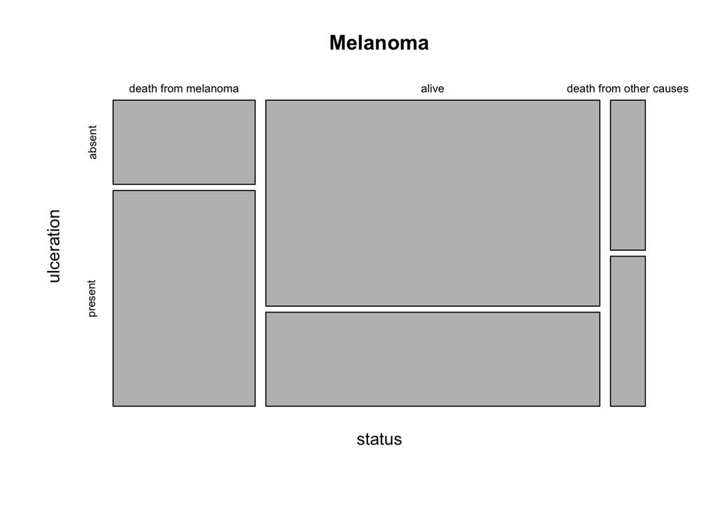

```r
Melanoma$status <- factor(Melanoma$status, levels = c(1, 2, 3), labels = c(
  "death from melanoma", "alive", "death from other causes"))

Melanoma$ulcer <- factor(Melanoma$ulcer, levels = c(0, 1),
                         labels = c("absent", "present"))


tab_statUlcer <- table(Melanoma$status, Melanoma$ulcer)

mosaicplot(tab_statUlcer, main = "Melanoma", xlab = "status",
           ylab = "ulceration")
```

```r
tab_statUlcer_pt <- rbind(tab_statUlcer, colSums(tab_statUlcer))
tab_statUlcer_pt <- cbind(tab_statUlcer_pt, rowSums(tab_statUlcer_pt))


row.names(tab_statUlcer_pt) <- c(row.names(tab_statUlcer), "total")

colnames(tab_statUlcer_pt) <- c(colnames(tab_statUlcer), "total")

tab_statUlcer_pt
```

```
                        absent present total
death from melanoma         16      41    57
alive                       92      42   134
death from other causes      7       7    14
total                      115      90   205
```

```r
# OR_12 = ((41/90) / (42/90)) / ((16/115) / (92/115)) = (41/42) / (16/92)
OR_12 <- (41 * 92) / (42 * 16)
OR_12
```

```
[1] 5.613095
```

```r
# OR_32 = ((7/90) / (42/90)) / ((7/115) / (92/115)) = (7/42) / (7/92)
OR_32 <- (7 * 92) / (42 * 7)
OR_32
```

```
[1] 2.190476
```

#### (b) Univariable multinomial model

Fit a multinomial model with status as dependent variable and ulcer as explanatory variable. Which estimated coefficients show the odds ratios calculated in (a)? Calculate their 95% confidence intervals. Is there evidence for an association between tumor ulceration and the different odds of death?

**Hints:** to set the reference levels of a factor, use function `relevel()`. To calculate confidence intervals for model estimated coefficients, use function `confint()` or `tidy()` from package `broom`.

```r
# Set the reference levels of the variables "status" and
# "ulcer":
Melanoma$status <- relevel(Melanoma$status, ref = "alive")
Melanoma$ulcer <- relevel(Melanoma$ulcer, ref = "absent")


multinom_melanom <- multinom(status ~ ulcer, data = Melanoma)
summary(multinom_melanom)
```

```
Call:
multinom(formula = status ~ ulcer, data = Melanoma)

Coefficients:
                        (Intercept) ulcerpresent
death from melanoma       -1.749391    1.7253372
death from other causes   -2.576088    0.7843716

Std. Errors:
                        (Intercept) ulcerpresent
death from melanoma       0.2708849    0.3486810
death from other causes   0.3921105    0.5660522

Residual Deviance: 307.6056
AIC: 315.6056
```

```r
exp(coef(multinom_melanom))
```

```
                        (Intercept) ulcerpresent
death from melanoma      0.17387979     5.614414
death from other causes  0.07607098     2.191030
```

```r
exp(confint(multinom_melanom, level = 0.95))
```

```
, , death from melanoma

                 2.5 %     97.5 %
(Intercept)  0.1022519  0.2956833
ulcerpresent 2.8346968 11.1199348

, , death from other causes

                  2.5 %   97.5 %
(Intercept)  0.03527394 0.164053
ulcerpresent 0.72247657 6.644660
```

#### (c) Multivariable multinomial model

Assess again the association of tumor ulceration with the different odds of dying versus staying alive after adjusting the multinomial model for patients’ age and sex. Check how the estimated odds ratios change and calculate their confidence intervals.

```r
summary(multinom_melanom2)
```

```
Call:
multinom(formula = status ~ ulcer + age + sex, data = Melanoma)

Coefficients:
                        (Intercept) ulcerpresent        age       sex
death from melanoma       -2.703762    1.6152588 0.01474460 0.5749964
death from other causes   -6.419789    0.4821069 0.06459613 0.5471406

Std. Errors:
                        (Intercept) ulcerpresent        age       sex
death from melanoma       0.6316782    0.3542286 0.01059397 0.3475052
death from other causes   1.4029755    0.5972308 0.02175049 0.5919900

Residual Deviance: 292.6505
AIC: 308.6505
```

```r
exp(coef(multinom_melanom2))
```

```
                        (Intercept) ulcerpresent      age      sex
death from melanoma      0.06695313     5.029189 1.014854 1.777124
death from other causes  0.00162900     1.619483 1.066728 1.728304
```

```r
exp(confint(multinom_melanom2, level = 0.95))
```

```
, , death from melanoma

                  2.5 %     97.5 %
(Intercept)  0.01941268  0.2309172
ulcerpresent 2.51175959 10.0697315
age          0.99399887  1.0361464
sex          0.89933349  3.5116787

, , death from other causes

                    2.5 %     97.5 %
(Intercept)  0.0001041613 0.02547629
ulcerpresent 0.5023571442 5.22083709
age          1.0222089750 1.11318616
sex          0.5416482033 5.51471342
```

#### (d) Odds estimated from the multivariable multinomial model

What is the odds of dying from melanoma for a 75-year old man without tumor ulceration?

**Hint:** the reference level of variable sex is 0 = female. The odds in question can be calculated manually just by looking the model estimated coefficients, but also using the output of `predict()`.

```r
exp(-2.703762 + 0.01474460 * 75 + 0.5749964)
```

```
[1] 0.3595433
```

```r
# or

pred_noUlcer_75_male <- predict(
  multinom_melanom2, newdata = data.frame(ulcer = "absent", age = 75, sex = 1),
  type = "probs")

pred_noUlcer_75_male["death from melanoma"] / pred_noUlcer_75_male["alive"]
```

```
death from melanoma
          0.3595431
```

#### (e) Probabilities estimated from the multivariable multinomial model

Calculate the probability of dying from melanoma for a 50-year old woman with tumor ulceration.

**Hint:** Use function `predict()`. The probability in question can be also calculated manually given the model-estimated odds:

$$log \biggl(\frac{P[status = \textit{death from melanoma} \ | \ ulcer = present]}{P[status = alive \ | \ ulcer = present]} \biggr)$$
$$log \biggl(\frac{P[status = \textit{death from other causes} \ | \ ulcer = present]}{P[status = alive \ | \ ulcer = present]} \biggr)$$
and given that
$$P[status = \textit{death from melanoma} \ | \ ulcer = present] + P[status = \textit{death from other causes} \ | \ ulcer = present] + P[status = alive \ | \ ulcer = present] = 1$$

```r
predict(
  multinom_melanom2, newdata = data.frame(ulcer = "present", age = 50, sex = 0),
  type = "probs")
```

```
                  alive     death from melanoma death from other causes
             0.56482198              0.39751663              0.03766139
```

```r
# Manual calculation:
# The odds of dying from melanoma versus staying alive for a 50-year old woman
# with tumor ulceration is:
# exp(-2.703762 + 1.6152588 + 0.01474460 * 50) = 0.7037915

# This odds is equal to the probability of dying from melanoma over the
# probability of staying alive for a 50-year old woman with tumor ulceration:

# P[status = "death from melanoma" | ulcer = "present"] / P[status = "alive" | ulcer = "present"] = 0.7037915

# meaning that:
# P[status = "death from melanoma" | ulcer = "present"] = 0.7037915 * P[status = "alive" | ulcer = "present"]


# The odds of dying from other causes versus staying alive for a 50-year old
# woman with tumor ulceration is:
# exp(-6.419789 + 0.4821069 + 0.06459613 * 50) = 0.06667831

# This odds is equal to the probability of dying from from other causes over the
# probability of staying alive for a 50-year old woman with tumor ulceration.

# P[status = "death from other causes" | ulcer = "present"] / P[status = "alive" | ulcer = "present"] = 0.06667831

# meaning that:
# P[status = "death from other causes" | ulcer = "present"] = 0.06667831 * P[status = "alive" | ulcer = "present"]


# We also know that:
# P[status = "death from melanoma" | ulcer = "present"] +
#   P[status = "death from other causes" | ulcer = "present"] +
#   P[status = "alive" | ulcer = "present"] = 1

# meaning that:
# P[status = "alive" | ulcer = "present"] = 1 - P[status = "death from melanoma" | ulcer = "present"] -
#   P[status = "death from other causes" | ulcer = "present"]
# P[status = "alive" | ulcer = "present"] = 1 - 0.06667831 * P[status = "alive" | ulcer = "present"] -
#   0.7037915 * P[status = "alive" | ulcer = "present"]
# P[status = "alive" | ulcer = "present"] = 1 - 0.06667831 * P[status = "alive" | ulcer = "present"] -
#   0.7037915 * P[status = "alive" | ulcer = "present"]
# P[status = "alive" | ulcer = "present"] = 1 - 0.7704698 * P[status = "alive" | ulcer = "present"]
# P[status = "alive" | ulcer = "present"] + 0.7704698 * P[status = "alive" | ulcer = "present"] = 1
# 1.77047 * P[status = "alive" | ulcer = "present"] = 1
# P[status = "alive" | ulcer = "present"] = 1 / 1.77047 = 0.5648218

# Now we can can calculate the  probability of dying from melanoma for a 50-year
# old woman with tumor ulceration:
# P[status = "death from melanoma" | ulcer = "present"] = 0.7037915 * 0.5648218 = 0.3975168
```

## Exercise 2

Using data from a questionnaire on the benefits of mammography (source: Applied Logistic Regression, 2nd edition, by Hosmer and Lemeshow, 2000) completed by 412 women, we would like to investigate women’s agreement to the statement: ‘You do not need a mammogram unless you develop symptoms.’, depending on their mother’s and sister’s breast cancer history.

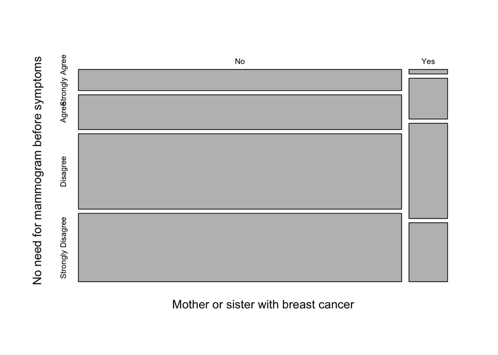

```r
tab_SYMPT_HIST <- table(mammoexp$SYMPT, mammoexp$HIST)

mosaicplot(t(tab_SYMPT_HIST),
           xlab = "Mother or sister with breast cancer",
           ylab = "No need for mammogram before symptoms", main = "")
```

```r
tab_SYMPT_HIST <- rbind(tab_SYMPT_HIST, colSums(tab_SYMPT_HIST))
tab_SYMPT_HIST <- cbind(tab_SYMPT_HIST, rowSums(tab_SYMPT_HIST))


row.names(tab_SYMPT_HIST) <- c(
  row.names(tab_SYMPT_HIST)[-nrow(tab_SYMPT_HIST)], "total")

colnames(tab_SYMPT_HIST) <- c(
  colnames(tab_SYMPT_HIST)[-ncol(tab_SYMPT_HIST)], "total")

tab_SYMPT_HIST
```

```
                   No Yes total
Strongly Agree     39   1    40
Agree              64   9    73
Disagree          139  21   160
Strongly Disagree 126  13   139
total             368  44   412
```

#### (a) Univariable ordinal logistic regression model

Fit an ordinal logistic regression model with `SYMPT` as dependent variable and `HIST` as explanatory variable. Which coefficient shows the change in the log-odds for women with a mother and/or sister with breast cancer history)? Is there evidence for an association between women’s agreement to the statement and their mother’s and sister’s breast cancer history?

```r
ordLog_mammo <- polr(SYMPT ~ HIST, data = mammoexp, method = "logistic")

ordLog_mammo_sum <- summary(ordLog_mammo)
ordLog_mammo_sum
```

```
Call:
polr(formula = SYMPT ~ HIST, data = mammoexp, method = "logistic")

Coefficients:
          Value Std. Error t value
HISTYes 0.05719     0.2805  0.2039

Intercepts:
                           Value    Std. Error t value
Strongly Agree|Agree        -2.2236   0.1693   -13.1318
Agree|Disagree              -0.9662   0.1153    -8.3793
Disagree|Strongly Disagree   0.6817   0.1092     6.2410

Residual Deviance: 1043.925
AIC: 1051.925
```

```r
exp(ordLog_mammo_sum$coefficients)
```

```
                               Value Std. Error      t value
HISTYes                    1.0588590   1.323760 1.226188e+00
Strongly Agree|Agree       0.1082223   1.184508 1.981250e-06
Agree|Disagree             0.3805091   1.122224 2.295608e-04
Disagree|Strongly Disagree 1.9771557   1.115411 5.133774e+02
```

```r
exp(confint(ordLog_mammo, level = 0.95))
```

```
    2.5 %    97.5 %
0.6121087 1.8427174
```

#### (b) Odds estimated from the univariable ordinal logistic model

What’s the odds of strongly agreeing or agreeing versus disagreeing or strongly disagreeing to the statement of interest for women with a mother and/or sister with breast cancer history, and for women whose mother and sister didn’t have breast cancer history? What do the other intercepts mean?

```r
exp(ordLog_mammo_sum$coefficients["Agree|Disagree", "Value"] -
      ordLog_mammo_sum$coefficients["HISTYes", "Value"])
```

```
[1] 0.3593577
```

```r
exp(ordLog_mammo_sum$coefficients["Agree|Disagree", "Value"])
```

```
[1] 0.3805091
```

#### (c) Proportional odds assumption meaning and visualization

The ordinal logistic model we fitted in (a) assumes proportionality of odds. What does this mean? Try to visualize this hypothesis.

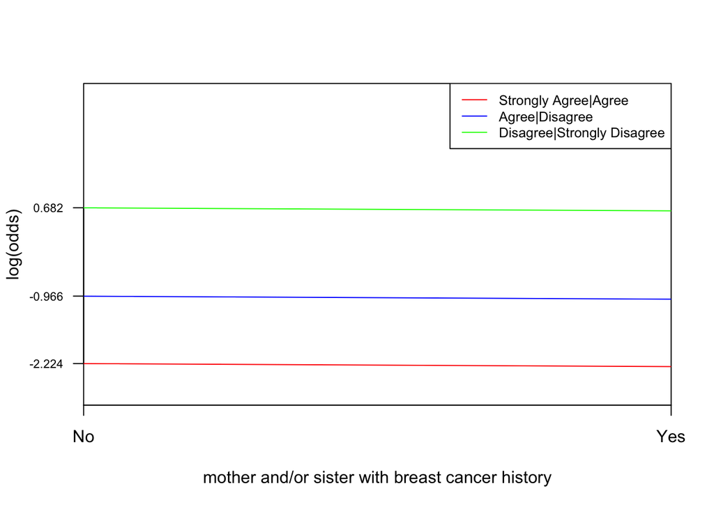

```r
plot(x = 1, ylim = c(-3, 3), xlim = c(0, 1), type = "n", xaxs = "i", xaxt = "n",
     yaxt = "n", yaxs = "i", ylab = "log(odds)",
     xlab = "mother and/or sister with breast cancer history")
axis(side = 1, at = c(0, 1), labels = c("No", "Yes"))
axis(side = 2, at = round(ordLog_mammo_sum$coefficients[
  which(row.names(ordLog_mammo_sum$coefficients) != "HISTYes"), "Value"], 3),
  las = 1, cex.axis = 0.7)


abline(coef = c(
  ordLog_mammo_sum$coefficients["Strongly Agree|Agree", "Value"],
  -ordLog_mammo_sum$coefficients["HISTYes", "Value"]), col = "red")

abline(coef = c(
  ordLog_mammo_sum$coefficients["Agree|Disagree", "Value"],
  -ordLog_mammo_sum$coefficients["HISTYes", "Value"]), col = "blue")

abline(coef = c(
  ordLog_mammo_sum$coefficients["Disagree|Strongly Disagree", "Value"],
  -ordLog_mammo_sum$coefficients["HISTYes", "Value"]), col = "green")

legend("topright", col = c("red", "blue", "green"), lty = rep(1, 3), legend = c(
  "Strongly Agree|Agree", "Agree|Disagree", "Disagree|Strongly Disagree"),
  cex = 0.8)
```

#### (d) Univariable multinomial regression model

After fitting a multinomial model to the data (again with `SYMPT` as dependent variable and `HIST` as explanatory variable), calculate the log-odds estimated by the ordinal logistic model given the probabilities estimated from the multinomial model.

**Hint:** Use `predict()` plugging in the multinomial model to estimate the following probabilities:

- probability of strongly agreeing to the statement for women with a mother and/or sister with breast cancer history and for women without breast cancer history
- probability of agreeing to the statement for women with a mother and/or sister with breast cancer history and for women without breast cancer history
- probability of disagreeing to the statement for women with a mother and/or sister with breast cancer history and for women without breast cancer history
- probability of strongly disagreeing to the statement for women with a mother and/or sister with breast cancer history and for women without breast cancer history

We have to then plug these probabilities into the following log-odds:

- $log \biggl(\frac{P[SYMPT = \textit{Strongly Agree} \ | \ HIST = No]}{P[SYMPT = \textit{Agree or Disagree or Strongly Disagree} \ | \ HIST = No]} \biggr) = log \biggl(\frac{P[SYMPT = \textit{Strongly Agree} \ | \ HIST = No]}{P[SYMPT = \textit{Agree} \ | \ HIST = No] + P[SYMPT = \textit{Disagree} \ | \ HIST = No] + P[SYMPT = \textit{Strongly Disagree} \ | \ HIST = No]} \biggr)$
- $log \biggl(\frac{P[SYMPT = \textit{Strongly Agree or Agree} \ | \ HIST = No]}{P[SYMPT = \textit{Disagree or Strongly Disagree} \ | \ HIST = No]} \biggr) = log \biggl(\frac{P[SYMPT = \textit{Strongly Agree} \ | \ HIST = No] + P[SYMPT = \textit{Agree} \ | \ HIST = No]}{P[SYMPT = \textit{Disagree} \ | \ HIST = No] + P[SYMPT = \textit{Strongly Disagree} \ | \ HIST = No]} \biggr)$
- $log \biggl(\frac{P[SYMPT = \textit{Strongly Agree or Agree or Disagree} \ | \ HIST = No]}{P[SYMPT = \textit{Strongly Disagree} \ | \ HIST = No]} \biggr) = log \biggl(\frac{P[SYMPT = \textit{Strongly Agree} \ | \ HIST = No] + P[SYMPT = \textit{Agree} \ | \ HIST = No] + P[SYMPT = \textit{Disagree} \ | \ HIST = No]}{P[SYMPT = \textit{Strongly Disagree} \ | \ HIST = No]} \biggr)$
- $log \biggl(\frac{P[SYMPT = \textit{Strongly Agree} \ | \ HIST = Yes]}{P[SYMPT = \textit{Agree or Disagree or Strongly Disagree} \ | \ HIST = Yes]} \biggr) = log \biggl(\frac{P[SYMPT = \textit{Strongly Agree} \ | \ HIST = Yes]}{P[SYMPT = \textit{Agree} \ | \ HIST = Yes] + P[SYMPT = \textit{Disagree} \ | \ HIST = Yes] + P[SYMPT = \textit{Strongly Disagree} \ | \ HIST = Yes]} \biggr)$
- $log \biggl(\frac{P[SYMPT = \textit{Strongly Agree or Agree} \ | \ HIST = Yes]}{P[SYMPT = \textit{Disagree or Strongly Disagree} \ | \ HIST = Yes]} \biggr) = log \biggl(\frac{P[SYMPT = \textit{Strongly Agree} \ | \ HIST = Yes] + P[SYMPT = \textit{Agree} \ | \ HIST = Yes]}{P[SYMPT = \textit{Disagree} \ | \ HIST = Yes] + P[SYMPT = \textit{Strongly Disagree} \ | \ HIST = Yes]} \biggr)$
- $log \biggl(\frac{P[SYMPT = \textit{Strongly Agree or Agree or Disagree} \ | \ HIST = Yes]}{P[SYMPT = \textit{Strongly Disagree} \ | \ HIST = Yes]} \biggr) = log \biggl(\frac{P[SYMPT = \textit{Strongly Agree} \ | \ HIST = Yes] + P[SYMPT = \textit{Agree} \ | \ HIST = Yes] + P[SYMPT = \textit{Disagree} \ | \ HIST = Yes]}{P[SYMPT = \textit{Strongly Disagree} \ | \ HIST = Yes]} \biggr)$

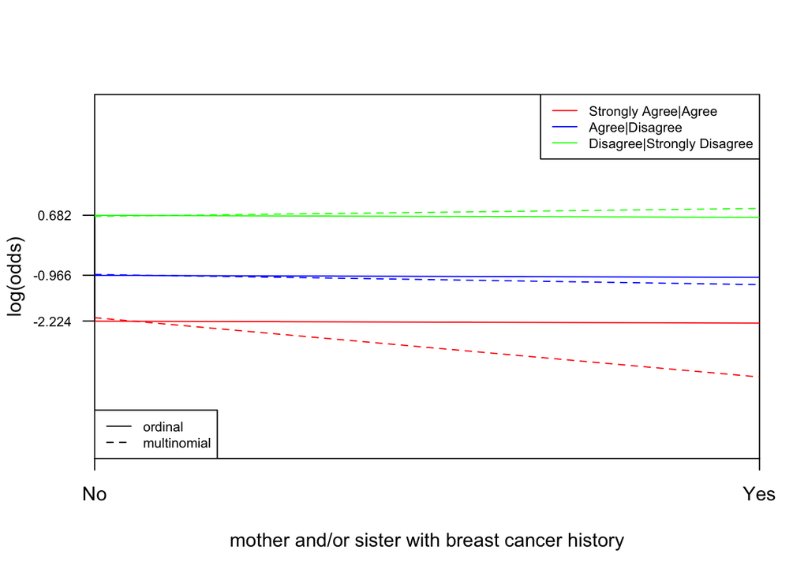

```r
multinom_mammo <- multinom(SYMPT ~ HIST, data = mammoexp)
multinom_mammo_sum <- summary(multinom_mammo)


# probabilities for women without breast cancer history ........................

pred_multi_no <- predict(
  multinom_mammo, newdata = data.frame(HIST = "No"), type = "probs")


# probabilities for women with a mother and/or sister with breast cancer history

pred_multi_yes <- predict(
  multinom_mammo, newdata = data.frame(HIST = "Yes"), type = "probs")


# log-odds for women without breast cancer history .............................

logOdds_StrAg_Agr_no <- log(
  pred_multi_no["Strongly Agree"] /
    (pred_multi_no["Agree"] + pred_multi_no["Disagree"] +
       pred_multi_no["Strongly Disagree"]))

logOdds_Agr_Disagr_no <- log(
  (pred_multi_no["Strongly Agree"] + pred_multi_no["Agree"]) /
  (pred_multi_no["Disagree"] + pred_multi_no["Strongly Disagree"]))

logOdds_Disagr_StrDisagr_no <- log(
  (pred_multi_no["Strongly Agree"] + pred_multi_no["Agree"] +
     pred_multi_no["Disagree"]) / pred_multi_no["Strongly Disagree"])


# log-odds for women with a mother and/or sister with breast cancer history ....

logOdds_StrAg_Agr_yes <- log(
  pred_multi_yes["Strongly Agree"] /
    (pred_multi_yes["Agree"] + pred_multi_yes["Disagree"] +
       pred_multi_yes["Strongly Disagree"]))

logOdds_Agr_Disagr_yes <- log(
  (pred_multi_yes["Strongly Agree"] + pred_multi_yes["Agree"]) /
  (pred_multi_yes["Disagree"] + pred_multi_yes["Strongly Disagree"]))

logOdds_Disagr_StrDisagr_yes <- log(
  (pred_multi_yes["Strongly Agree"] + pred_multi_yes["Agree"] +
     pred_multi_yes["Disagree"]) / pred_multi_yes["Strongly Disagree"])


# Slopes (for plotting the above-calculated log-odds together with the log-odds
# of the ordinal model) ........................................................

x <- c("No", "Yes")

y_StrAg_Agr <- c(logOdds_StrAg_Agr_no, logOdds_StrAg_Agr_yes)
slope_StrAg_Agr <- coefficients(lm(y_StrAg_Agr ~ x))["xYes"]

y_Agr_Disagr <- c(logOdds_Agr_Disagr_no, logOdds_Agr_Disagr_yes)
slope_Agr_Disagr <- coefficients(lm(y_Agr_Disagr ~ x))["xYes"]

y_Disagr_StrDisagr <- c(logOdds_Disagr_StrDisagr_no,
                        logOdds_Disagr_StrDisagr_yes)
slope_Disagr_StrDisagr <- coefficients(lm(y_Disagr_StrDisagr ~ x))["xYes"]


# Plot .........................................................................

plot(x = 1, ylim = c(-6, 4), xlim = c(0, 1), type = "n", xaxs = "i", xaxt = "n",
     yaxt = "n", yaxs = "i", ylab = "log(odds)",
     xlab = "mother and/or sister with breast cancer history")
axis(side = 1, at = c(0, 1), labels = c("No", "Yes"))
axis(side = 2, at = round(ordLog_mammo_sum$coefficients[
  which(row.names(ordLog_mammo_sum$coefficients) != "HISTYes"), "Value"], 3),
  las = 1, cex.axis = 0.7)


abline(coef = c(
  ordLog_mammo_sum$coefficients["Strongly Agree|Agree", "Value"],
  -ordLog_mammo_sum$coefficients["HISTYes", "Value"]), col = "red")

abline(coef = c(
  ordLog_mammo_sum$coefficients["Agree|Disagree", "Value"],
  -ordLog_mammo_sum$coefficients["HISTYes", "Value"]), col = "blue")

abline(coef = c(
  ordLog_mammo_sum$coefficients["Disagree|Strongly Disagree", "Value"],
  -ordLog_mammo_sum$coefficients["HISTYes", "Value"]), col = "green")


abline(coef = c(logOdds_StrAg_Agr_no, slope_StrAg_Agr), col = "red", lty = 2)

abline(coef = c(logOdds_Agr_Disagr_no, slope_Agr_Disagr), col = "blue", lty = 2)

abline(coef = c(logOdds_Disagr_StrDisagr_no, slope_Disagr_StrDisagr),
       col = "green", lty = 2)

legend("topright", col = c("red", "blue", "green"), lty = rep(1, 3), legend = c(
  "Strongly Agree|Agree", "Agree|Disagree", "Disagree|Strongly Disagree"),
  cex = 0.7)

legend("bottomleft", lty = c(1, 2), legend = c("ordinal", "multinomial"),
       cex = 0.7)
```

#### (e) Test for proportional odds assumption

Run a test to assess if there is evidence for a violation of the proportional odds assumption.

```r
G <- -2 * ((-ordLog_mammo$deviance/2) - (-multinom_mammo$deviance/2))

1 - pchisq(q = G, df = multinom_mammo$edf - ordLog_mammo$edf)
```

```
[1] 0.07074374
```

## Exercise 3

#### (a) Conditional logistic regression model

Fit a conditional logistic regression model including the number of prior induced and prior spontaneous abortions as explanatory variables. What is the impact of abortions on the risk of secondary infertility in women?

```r
condLog_infer <- clogit(case ~ spontaneous + induced + strata(stratum),
                        data = infert)

summary(condLog_infer)
```

```
Call:
coxph(formula = Surv(rep(1, 248L), case) ~ spontaneous + induced +
    strata(stratum), data = infert, method = "exact")

  n= 248, number of events= 83

              coef exp(coef) se(coef)     z Pr(>|z|)
spontaneous 1.9859    7.2854   0.3524 5.635 1.75e-08 ***
induced     1.4090    4.0919   0.3607 3.906 9.38e-05 ***
---
Signif. codes:  0 '***' 0.001 '**' 0.01 '*' 0.05 '.' 0.1 ' ' 1

            exp(coef) exp(-coef) lower .95 upper .95
spontaneous     7.285     0.1373     3.651    14.536
induced         4.092     0.2444     2.018     8.298

Concordance= 0.776  (se = 0.044 )
Likelihood ratio test= 53.15  on 2 df,   p=3e-12
Wald test            = 31.84  on 2 df,   p=1e-07
Score (logrank) test = 48.44  on 2 df,   p=3e-11
```